# Tipologia y ciclo de vida de los datos - PRA2

Vamos a generar el modelo de regresión lineal con los dos conjuntos de datos, uno de entrenamiento y otro de test, con el objetivo de ver como de bueno es el modelo.

```r
# Generamos los dos conjuntos de datos
set.seed(1701)
trainIndex <- createDataPartition(subdatos$quality, p = 0.8, list = FALSE)
train_data <- subdatos[trainIndex, ]
test_data <- subdatos[-trainIndex, ]


# Creamos un modelo reducido
modelo_reducido_lm <- (lm(formula = quality ~ alcohol + sulphates + volatile.acidity,
                          data = train_data))
summary(modelo_reducido_lm)
```

```
##
## Call:
## lm(formula = quality ~ alcohol + sulphates + volatile.acidity,
##     data = train_data)
##
## Residuals:
##      Min       1Q   Median       3Q      Max
## -2.05817 -0.38543 -0.08355  0.45826  1.98769
##
## Coefficients:
##                  Estimate Std. Error t value Pr(>|t|)
## (Intercept)        1.7715     0.2760   6.419 2.37e-10 ***
## alcohol            0.3111     0.0227  13.706  < 2e-16 ***
## sulphates          1.7148     0.2089   8.209 9.15e-16 ***
## volatile.acidity  -0.8465     0.1430  -5.921 4.80e-09 ***
## ---
## Signif. codes:  0 '***' 0.001 '**' 0.01 '*' 0.05 '.' 0.1 ' ' 1
##
## Residual standard error: 0.6109 on 782 degrees of freedom
## Multiple R-squared:  0.3787, Adjusted R-squared:  0.3763
## F-statistic: 158.9 on 3 and 782 DF,  p-value: < 2.2e-16
```

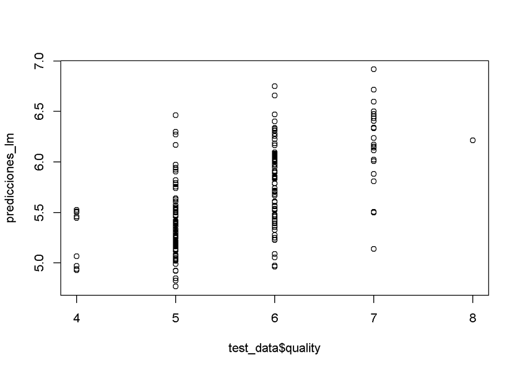

```r
# Predicción sobre los datos de test
predicciones_lm <- predict(modelo_reducido_lm, test_data)
plot(test_data$quality, predicciones_lm)
```

```r
# Creamos la matriz de confusión de los valores
matriz_confusion_lm <- table(test_data$quality ,
                             round(predicciones_lm),
                             dnn = c("observaciones", "predicciones"))
matriz_confusion_lm
```

```
##              predicciones
## observaciones  5  6  7
##             4  7  3  0
##             5 59 21  0
##             6 22 56  2
##             7  1 17  5
##             8  0  1  0
```

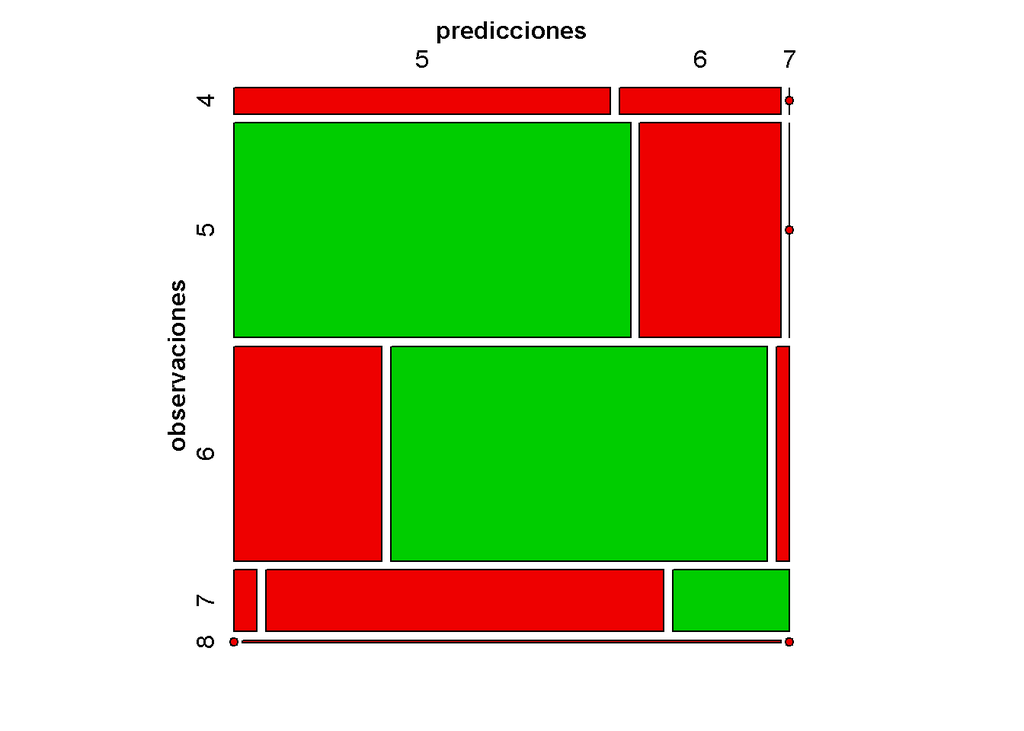

```r
# Matriz de confusión del modelo de regresión lineal con los tres parámetros significativos.
mosaic(matriz_confusion_lm,
       shade = T,
       colorize = T,
       gp = gpar(fill = matrix(c("red2",   "green3",   "red2",   "red2",   "red2",
                                 "red2",   "red2",     "green3", "red2",   "red2",
                                 "red2",   "red2",     "red2",   "green3", "red2"), 5, 3)))
```

Podemos observar que los valores obtenidos en la predicción están dentro del rango de valores esperado, por lo que el modelo está realizando correctamente los cálculos. En este caso observamos a partir de la matriz de confusión como el modelo tiene aproximadamente un 62% de acierto en la predicción.

La interpretación del modelo sería una equación lineal, que se puede recrear a partir de los parámetros obtenidos por el modelo.

### 3.2.2 Regresión logistica

Con el objetivo de tener un modelo que nos permitiera tener un control de calidad excluyente y que nos permitiera decidir si el producto final está dentro de los vinos considerados de alta calidad, con valoración de 6, 7 u 8. Vamos a crear un modelo de regresión logística y compararemos resultados.

```r
# Creamos una variable calidad de tipo factor
subdatos$quality_factor <- as.factor(subdatos$quality)

# Creamos un variable calidad binomial donde especificamos que queremos vinos
# con valoraciones de 6 o más.
subdatos$category[subdatos$quality < 6] <- 0
subdatos$category[subdatos$quality >= 6] <- 1
subdatos$category <- as.factor(subdatos$category)
```

Creamos el modelo de regresión logística

```r
# Generamos el modelo con las variables seleccionadas
modelo_log <- glm(category ~ alcohol + sulphates + volatile.acidity,
                  data = subdatos, family = "binomial")
summary(modelo_log)
```

```
##
## Call:
## glm(formula = category ~ alcohol + sulphates + volatile.acidity,
##     family = "binomial", data = subdatos)
##
## Deviance Residuals:
##     Min       1Q   Median       3Q      Max
## -2.6924  -0.8389   0.2923   0.8382   2.3321
##
## Coefficients:
##                   Estimate Std. Error z value Pr(>|z|)
## (Intercept)      -12.47164    1.11249 -11.211  < 2e-16 ***
## alcohol            1.02284    0.09456  10.817  < 2e-16 ***
## sulphates          5.29518    0.77638   6.820 9.08e-12 ***
## volatile.acidity  -2.29750    0.49250  -4.665 3.09e-06 ***
## ---
## Signif. codes:  0 '***' 0.001 '**' 0.01 '*' 0.05 '.' 0.1 ' ' 1
##
## (Dispersion parameter for binomial family taken to be 1)
##
##     Null deviance: 1353.0  on 979  degrees of freedom
## Residual deviance: 1025.2  on 976  degrees of freedom
## AIC: 1033.2
##
## Number of Fisher Scoring iterations: 4
```

Creamos la tabla de confusión correspondiente al modelo.

```r
predicciones <- ifelse(test = modelo_log$fitted.values > 0.5, yes = 1, no = 0)
matriz_confusion <- table(modelo_log$model$category ,
                          predicciones,
                          dnn = c("observaciones", "predicciones"))
matriz_confusion
```

```
##              predicciones
## observaciones   0   1
##             0 344 109
##             1 156 371
```

Visualizamos los resultados.

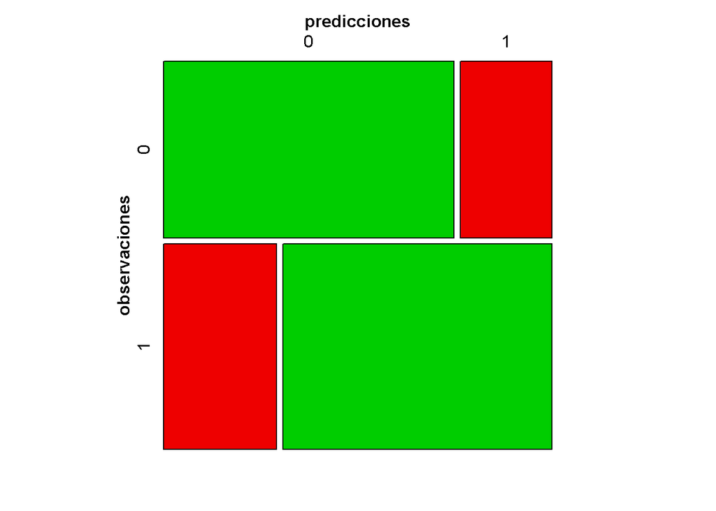

```r
mosaic(matriz_confusion,
       shade = T,
       colorize = T,
       gp = gpar(fill = matrix(c("green3", "red2", "red2", "green3"), 2, 2)))
```

El modelo de regresión logística nos ha dado un resultado de predicción de un 73% de acierto. Hemos de tener en cuenta que hemos simplificado la predicción a dos valores, considerando los vinos con puntuación de 5 o menos como malos y de 6, 7 u 8 como buenos. En este caso, hemos entrenado el modelo con todos los datos y lo hemos evaluado sobre los mimos datos.

Vamos a crear un modelo predictivo sobre la variable quality, dividiendo los datos en un conjunto de entrenamiento y otro de test. En este caso, vamos a intentar precedir la calidad del vino en todas sus categorias en función de los parámetros.

```r
# Generamos los dos conjuntos de datos
set.seed(1234)
trainIndex <- createDataPartition(subdatos$quality, p = 0.8, list = FALSE)
train_data <- subdatos[trainIndex, ]
test_data <- subdatos[-trainIndex, ]

# Generamos nuestro modelo de regresión logística con las variables escogidas
modelo_reducido_glm <- glm(quality ~ alcohol + sulphates + volatile.acidity,
                           data = train_data, family = "gaussian")
summary(modelo_reducido_glm)
```

```
##
## Call:
## glm(formula = quality ~ alcohol + sulphates + volatile.acidity,
##     family = "gaussian", data = train_data)
##
## Deviance Residuals:
##      Min        1Q    Median        3Q       Max
## -2.02630  -0.37656  -0.07482   0.46472   1.99944
##
## Coefficients:
##                  Estimate Std. Error t value Pr(>|t|)
## (Intercept)       1.55313    0.27832   5.580 3.31e-08 ***
## alcohol           0.32456    0.02331  13.924  < 2e-16 ***
## sulphates         1.77793    0.21136   8.412  < 2e-16 ***
## volatile.acidity -0.79527    0.13908  -5.718 1.53e-08 ***
## ---
## Signif. codes:  0 '***' 0.001 '**' 0.01 '*' 0.05 '.' 0.1 ' ' 1
##
## (Dispersion parameter for gaussian family taken to be 0.3825123)
##
##     Null deviance: 485.66  on 785  degrees of freedom
## Residual deviance: 299.12  on 782  degrees of freedom
## AIC: 1481.2
##
## Number of Fisher Scoring iterations: 2
```

Probamos el modelo con los datos de test. Las predicciones son de valores continuos, y en nuestro caso tenemos valores categóricos, por lo que realizaremos un ajuste del resultado por redondeo para obtener la matriz de confusión.

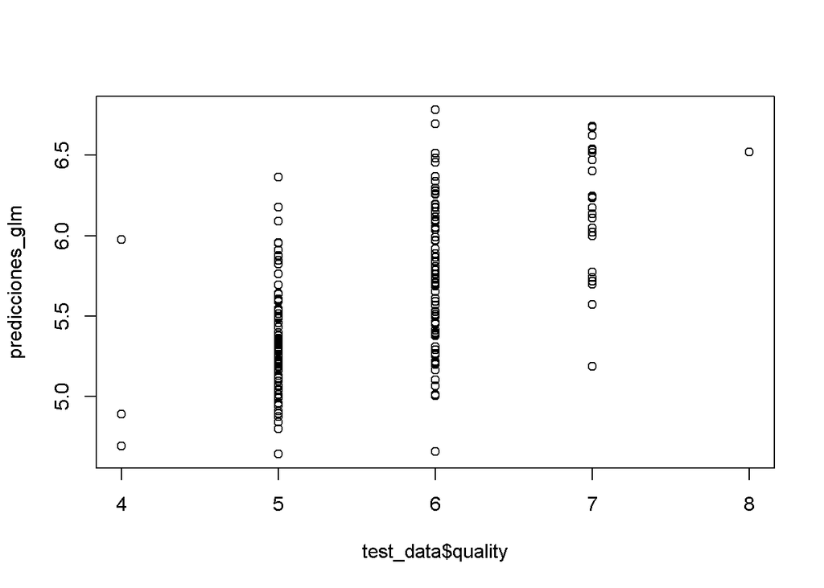

```r
# Predicción sobre los datos de test
predicciones_glm <- predict(modelo_reducido_glm, test_data)
plot(test_data$quality, predicciones_glm)
```

```r
# Creamos la matriz de confusión de los valores
matriz_confusion_glm <- table(test_data$quality ,
                              round(predicciones_glm),
                              dnn = c("observaciones", "predicciones"))
matriz_confusion_glm
```

```
##              predicciones
## observaciones  5  6  7
##             4  2  1  0
##             5 62 25  0
##             6 26 51  3
##             7  1 16  6
##             8  0  0  1
```

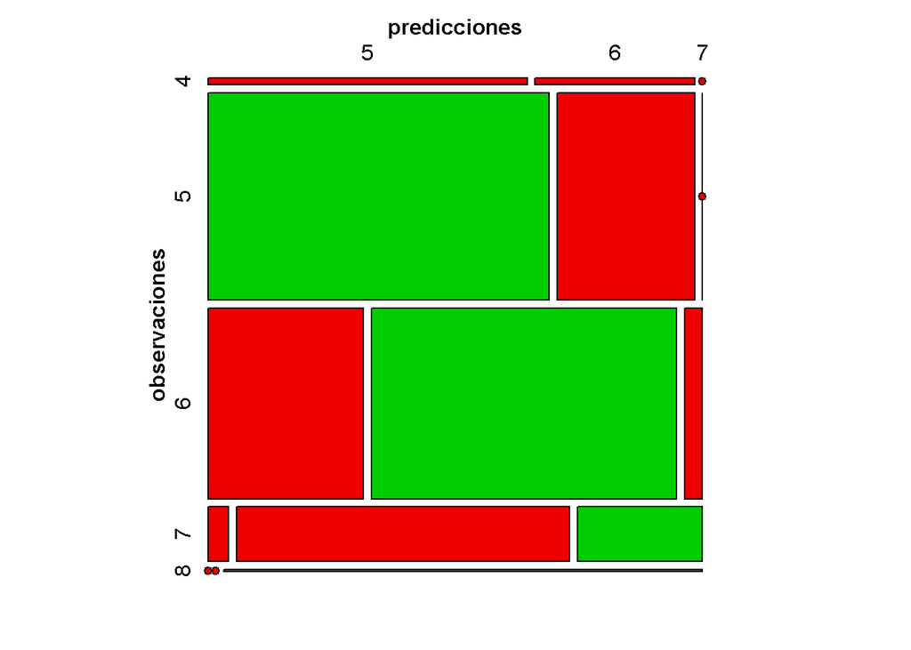

```r
# Visualizamos la matriz de confusión
mosaic(matriz_confusion_glm,
       shade = T,
       colorize = T,
       gp = gpar(fill = matrix(c("red2",   "green3",   "red2",   "red2",   "red2",
                                 "red2",   "red2",     "green3", "red2",   "red2",
                                 "red2",   "red2",     "red2",   "green3", "red2"), 5, 3)))
```

Podemos observar que los valores obtenidos en la predicción están dentro del rango de valores esperado, por lo que el modelo está realizando correctamente los cálculos. En este caso observamos a partir de la matriz de confusión como el modelo tiene un 61,34% de acierto en la predicción.

### 3.2.3 Modelos de clasificacion

También nos seria útil tener algún modelo de clasificación que pudiéramos determinar la calidad del vino en función de sus características. Podría agrupar los productos o producción en varios productos de venta, etc… Crearemos un modelo supervisado.

#### 3.2.3.1 Arbol de decision

Necesitaremos prepara los datos para crear un grupo de datos de entrenamiento y de prueba.

```r
# Copiamos los datos y eliminamos algunas columnas
datos_arbol <- subdatos
datos_arbol$quality <- NULL
datos_arbol$quality_factor <- NULL
#datos_arbol$category <- NULL
# Creamos los conjuntos de datos de entrenamiento y de test.
set.seed(666)
datos_training <- sample_frac(datos_arbol, .7)
datos_test <- setdiff(datos_arbol, datos_training)
```

Entrenamos el modelo basándonos en la variable categoria

```r
arbol <- rpart(formula = category~ ., data = datos_training)
```

Evaluando el modelo

```r
arbol
```

```
## n= 686
##
## node), split, n, loss, yval, (yprob)
##       * denotes terminal node
##
##  1) root 686 301 1 (0.4387755 0.5612245)
##    2) alcohol< 10.45 388 147 0 (0.6211340 0.3788660)
##      4) sulphates< 0.625 253  70 0 (0.7233202 0.2766798) *
##      5) sulphates>=0.625 135  58 1 (0.4296296 0.5703704)
##       10) volatile.acidity>=0.565 52  19 0 (0.6346154 0.3653846)
##         20) alcohol< 9.85 33   7 0 (0.7878788 0.2121212) *
##         21) alcohol>=9.85 19   7 1 (0.3684211 0.6315789) *
##       11) volatile.acidity< 0.565 83  25 1 (0.3012048 0.6987952) *
##    3) alcohol>=10.45 298  60 1 (0.2013423 0.7986577)
##      6) sulphates< 0.585 82  34 1 (0.4146341 0.5853659)
##       12) alcohol< 11.1 33  10 0 (0.6969697 0.3030303) *
##       13) alcohol>=11.1 49  11 1 (0.2244898 0.7755102) *
##      7) sulphates>=0.585 216  26 1 (0.1203704 0.8796296) *
```

Mostramos el arbol de desicion con la funcion plot

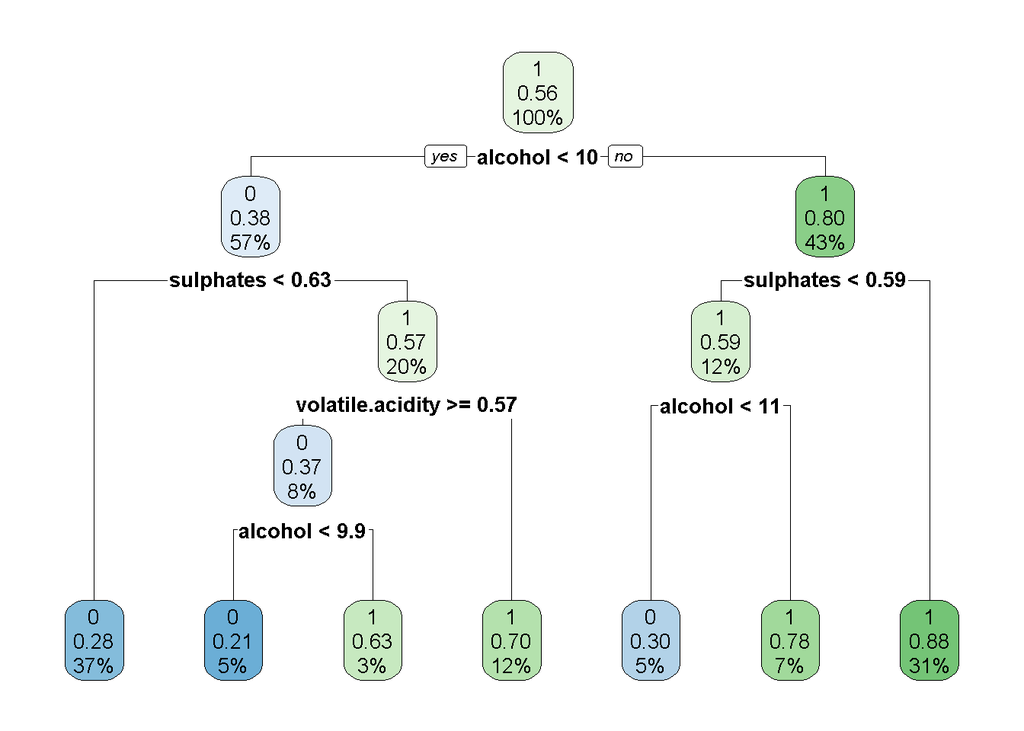

```r
rpart.plot(arbol)
```

Creamos la matrix de confusion para evaluar el arbol.

```r
prediccion <- predict(arbol, newdata = datos_test, type = "class")
confusionMatrix(prediccion, datos_test[["category"]])
```

```
## Confusion Matrix and Statistics
##
##           Reference
## Prediction   0   1
##          0 110  47
##          1  41  95
##
##                Accuracy : 0.6997
##                  95% CI : (0.6436, 0.7516)
##     No Information Rate : 0.5154
##     P-Value [Acc > NIR] : 1.076e-10
##
##                   Kappa : 0.398
##
##  Mcnemar's Test P-Value : 0.594
##
##             Sensitivity : 0.7285
##             Specificity : 0.6690
##          Pos Pred Value : 0.7006
##          Neg Pred Value : 0.6985
##              Prevalence : 0.5154
##          Detection Rate : 0.3754
##    Detection Prevalence : 0.5358
##       Balanced Accuracy : 0.6987
##
##        'Positive' Class : 0
##
```

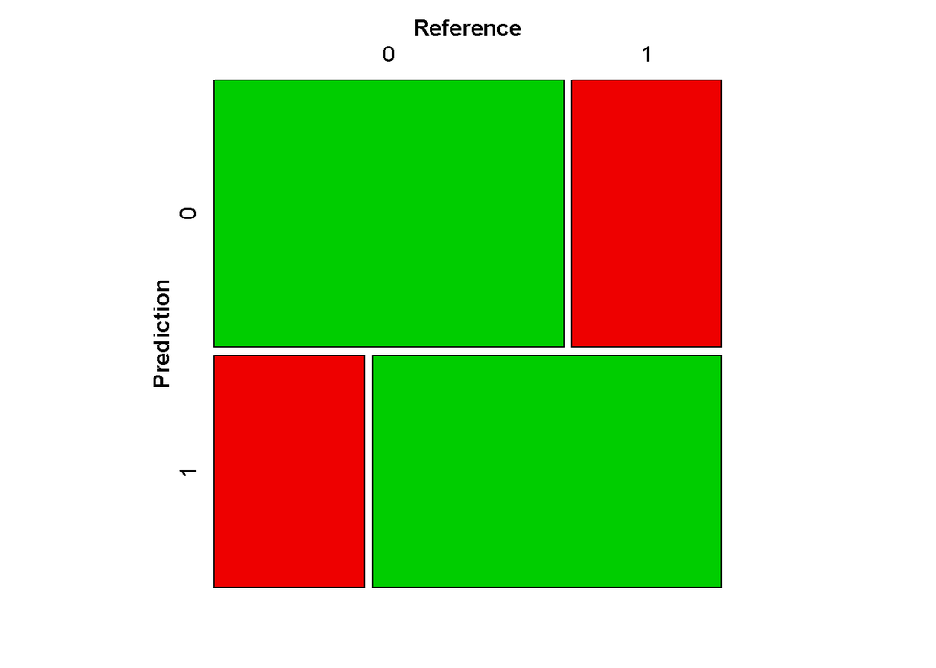

```r
confusionMatrix_table <- confusionMatrix(prediccion, datos_test[["category"]])$table

mosaic(confusionMatrix_table,
       shade = T,
       colorize = T,
       gp = gpar(fill = matrix(c("green3", "red2", "red2", "green3"), 2, 2)))
```

# 4 Representación de los resultados

A partir del conjunto de datos inicial, y tras una revisión y eliminación de valores perdidos, elementos duplicados y valores extremos, se ha obtenido un conjunto de datos limpios con el cual empezar a analizar.

```r
summary(datos_clean)
```

```
##  fixed.acidity    volatile.acidity  citric.acid    residual.sugar
##  Min.   : 5.100   Min.   :0.1200   Min.   :0.000   Min.   :1.200
##  1st Qu.: 7.100   1st Qu.:0.3900   1st Qu.:0.080   1st Qu.:1.900
##  Median : 7.800   Median :0.5200   Median :0.240   Median :2.100
##  Mean   : 8.155   Mean   :0.5216   Mean   :0.249   Mean   :2.196
##  3rd Qu.: 9.000   3rd Qu.:0.6300   3rd Qu.:0.400   3rd Qu.:2.500
##  Max.   :12.300   Max.   :1.0100   Max.   :0.730   Max.   :3.650
##    chlorides       free.sulfur.dioxide total.sulfur.dioxide    density
##  Min.   :0.03900   Min.   : 1.00       Min.   :  6.00       Min.   :0.9923
##  1st Qu.:0.06900   1st Qu.: 8.00       1st Qu.: 22.00       1st Qu.:0.9955
##  Median :0.07800   Median :13.00       Median : 36.00       Median :0.9965
##  Mean   :0.07841   Mean   :15.01       Mean   : 42.38       Mean   :0.9965
##  3rd Qu.:0.08700   3rd Qu.:20.00       3rd Qu.: 56.00       3rd Qu.:0.9976
##  Max.   :0.12200   Max.   :42.00       Max.   :124.00       Max.   :1.0010
##        pH          sulphates         alcohol         quality
##  Min.   :2.940   Min.   :0.3700   Min.   : 8.70   Min.   :3.00
##  1st Qu.:3.230   1st Qu.:0.5500   1st Qu.: 9.50   1st Qu.:5.00
##  Median :3.320   Median :0.6100   Median :10.10   Median :6.00
##  Mean   :3.322   Mean   :0.6313   Mean   :10.39   Mean   :5.64
##  3rd Qu.:3.400   3rd Qu.:0.7000   3rd Qu.:11.00   3rd Qu.:6.00
##  Max.   :3.680   Max.   :0.9800   Max.   :13.40   Max.   :8.00
```

Hemos analizado la distribución de los datos en función de la variable “quality” y hemos identificado visualmente los elementos que afectan significativamente a la calidad del vino, tanto positivamente como negativamente.

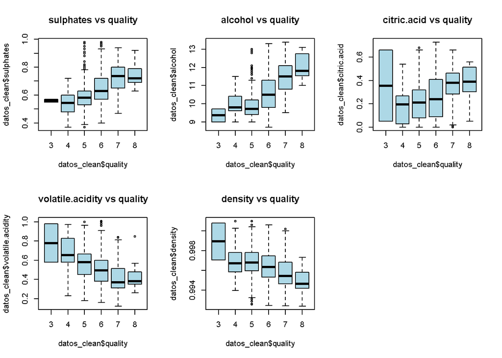

```r
par(mfrow=c(2,3))

boxplot(formula = datos_clean$sulphates ~ datos_clean$quality,
        main="sulphates vs quality", col="lightblue")
boxplot(formula = datos_clean$alcohol ~ datos_clean$quality,
        main="alcohol vs quality", col="lightblue")
boxplot(formula = datos_clean$citric.acid ~ datos_clean$quality,
        main="citric.acid vs quality", col="lightblue")
boxplot(formula = datos_clean$volatile.acidity ~ datos_clean$quality,
        main="volatile.acidity vs quality", col="lightblue")
boxplot(formula = datos_clean$density ~ datos_clean$quality,
        main="density vs quality", col="lightblue")
```

Hemos analizado la normalidad y homocedasticidad de los datos de este subconjunto.

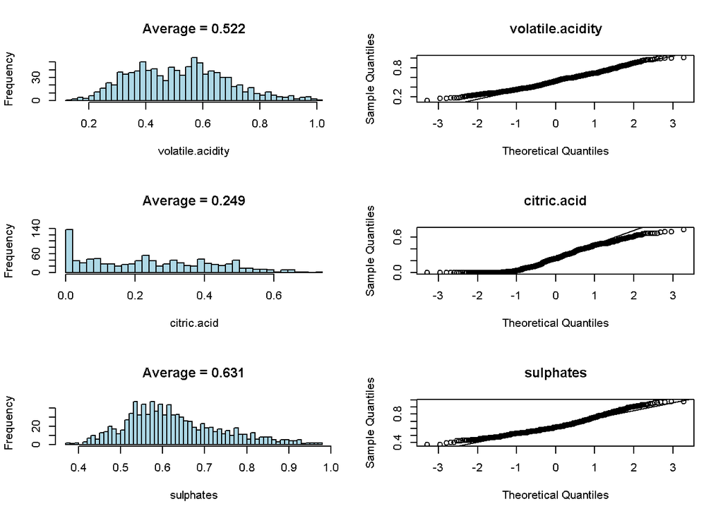

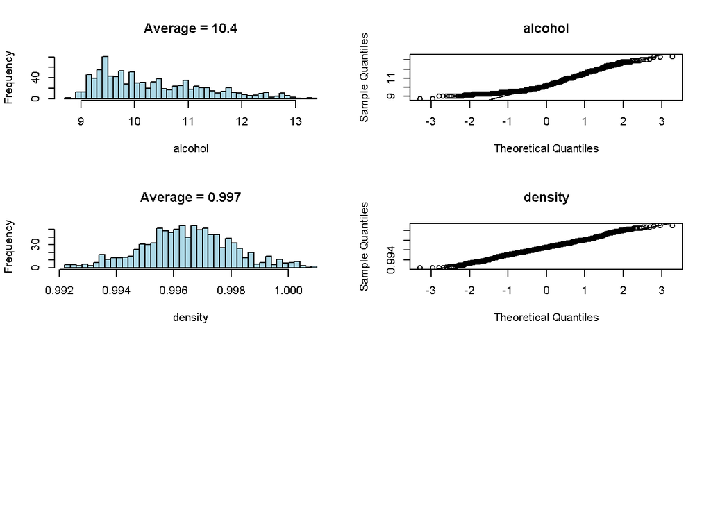

```r
# Gráficas QQ de comprobación de normalidad e histogramas
par(mfrow=c(3,2))
for (i in 1:5) {
  hist(subdatos[[i]],
       xlab = names(subdatos)[i],
       col = 'lightblue',
       main = paste("Average =", signif(mean(subdatos[[i]]),3)),
       breaks = 50)
  qqnorm(subdatos[,i], main = colnames(subdatos[i]))
  qqline(subdatos[,i])

}
```

Hemos analizado la correlación entre variables.

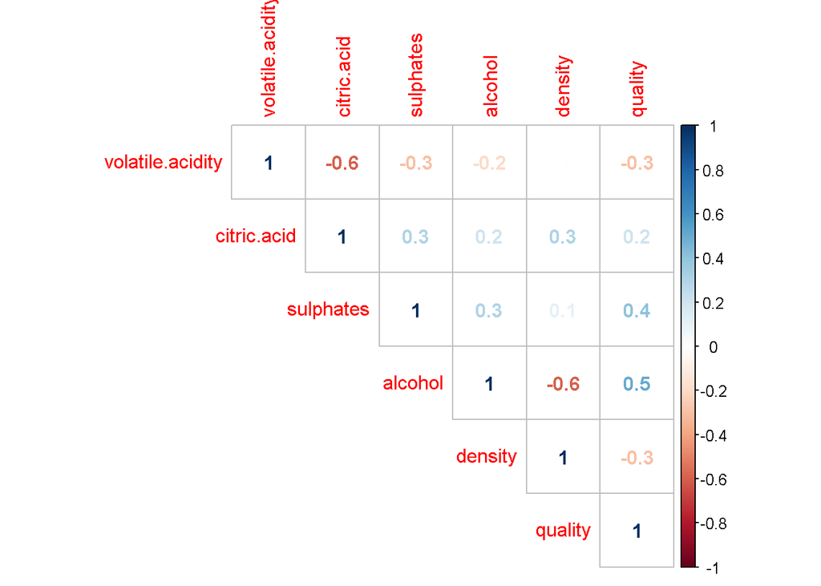

```r
corrplot(correlacion_sc, method="number", type="upper")
```

Con toda la información analizada, se ha decidido el analizar la creación de modelos de predicción y clasificación con estas variables.

Tras una primera versión de un modelo de regresión lineal, se ha detectado que el conjunto de variables siginificativas se puede reducir a tres, “alcohol”, “sulphates” y “Volatile.acidity”, sin que afecte al resultado del modelo.

Con estas variables hemos realizado varios modelos.

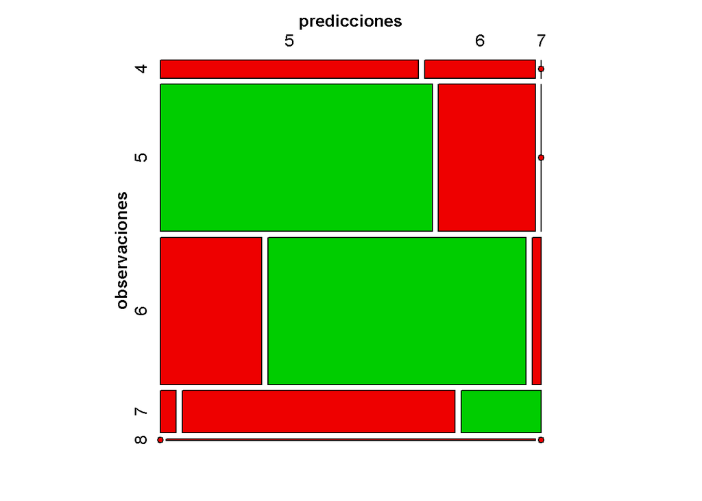

```r
# Matriz de confusión del modelo de regresión lineal con los tres parámetros significativos.
mosaic(matriz_confusion_lm,
       shade = T,
       colorize = T,
       gp = gpar(fill = matrix(c("red2",   "green3",   "red2",   "red2",   "red2",
                                 "red2",   "red2",     "green3", "red2",   "red2",
                                 "red2",   "red2",     "red2",   "green3", "red2"), 5, 3)))
```

En este caso observamos a partir de la matriz de confusión como el modelo tiene aproximadamente un 62% de acierto en la predicción.

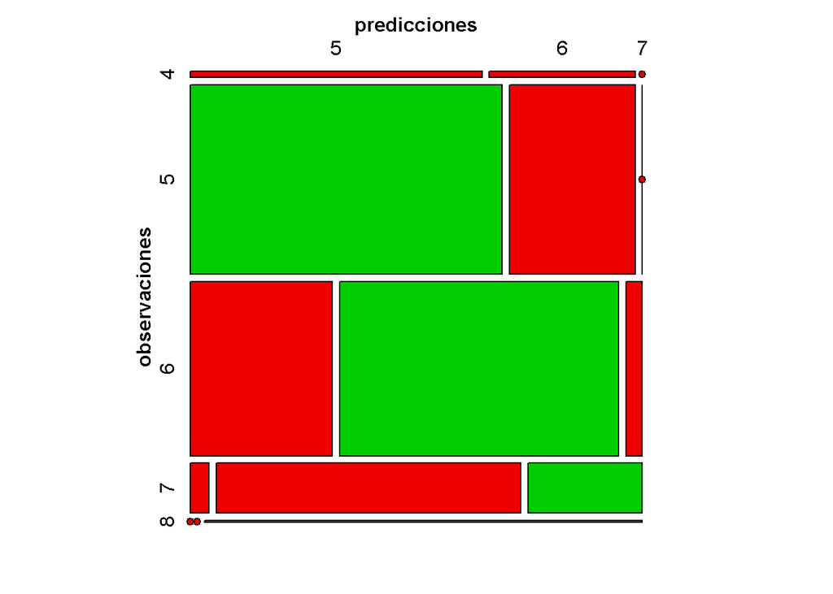

```r
# Matriz de confusión del modelo de regresión logística con los tres parámetros significativos.
mosaic(matriz_confusion_glm,
       shade = T,
       colorize = T,
       gp = gpar(fill = matrix(c("red2",   "green3",   "red2",   "red2",   "red2",
                                 "red2",   "red2",     "green3", "red2",   "red2",
                                 "red2",   "red2",     "red2",   "green3", "red2"), 5, 3)))
```

En este caso observamos a partir de la matriz de confusión como el modelo tiene un 61,34% de acierto en la predicción.

Ambos modelos de regresión nos das resultados muy similares.

Vamos a probar con un modelo de clasificación por árbol de decisión.

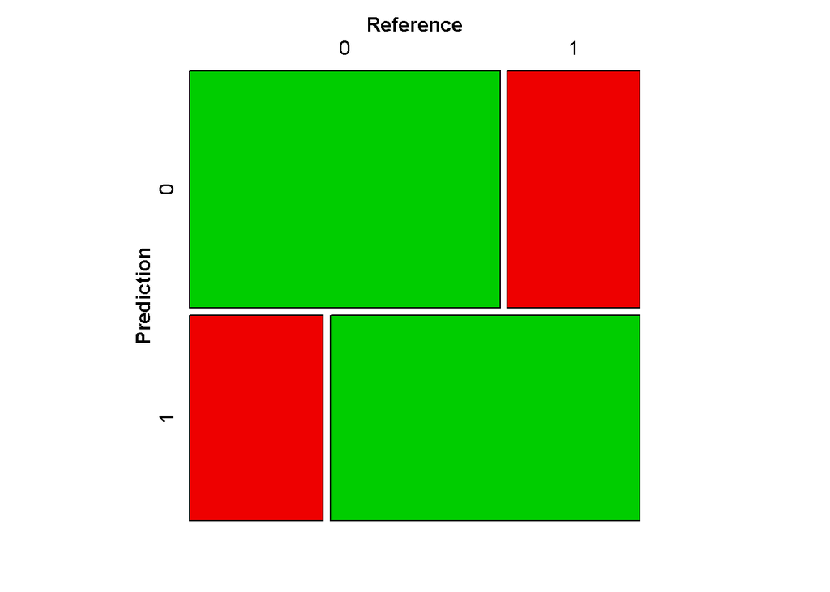

```r
# Matriz de confusión del modelo de clasificación por árbol de decisión con los tres
# parámetros significativos
mosaic(confusionMatrix_table,
       shade = T,
       colorize = T,
       gp = gpar(fill = matrix(c("green3", "red2", "red2", "green3"), 2, 2)))
```

# 5 Resolución del problema

Como conclusión, podemos decir que hay tres variables más representativas que el resto en la clasificación de calidad del vino, estas son “alcohol”, “sulphates” y “Volatile.acidity”.

A partir de dichas variables, y mediante un modelo de clasificación por árbol de decisión, podemos obtener con una predicción de la calidad del vino, con un nivel de acierto del 70%.